# Final Project

Marianela and Roi

4/18/2022

*R-markdown*

# 1 Introduction

Blood transfusion saves lives, from replacing lost blood during major surgery, a serious injury to treating various illnesses and blood disorders such as leukemia. Ensuring that there’s enough blood in supply whenever needed is a serious challenge for the health professionals. There is an approximation that every 2 seconds someone in the U.S. needs a blood transfusion.

During campaigns it is usually hard to convince people to donate blood. So, we decided to use a data set found on internet to make a model to predict blood transfusions.

Our dataset is from a mobile blood donation vehicle in Taiwan. The Blood Transfusion Service Center drives to different universities and collects blood as part of a blood drive. We want to predict whether or not a donor will give blood the next time the vehicle comes to campus.

## 1.1 Research Question

Our goal is to predict whether a person has donated blood or not in March 2007 based on the given predictors Recency(months), Frequency(times), Monetary(c.c. blood), Time(months).

# 2 Dataset description

## 2.1 Data

The data contains 748 data points and 5 variables. This data was collected by Blood Transfusion Service Center in Hsin-Chu City in Taiwan.

Observational Unit: one blood donor from Hsin-ChU city in Taiwan.

Data description:

| Variable | Description |
| --- | --- |
| Recency(months) | Number of months since the particular donor’s most recent donation |
| Frequency(times) | Total number of donations that the donor has made |
| Monetary(c.c.blood) | Total amount of blood that the donor has donated(cubic centimeters) |
| Time(months) | Number of months since the donor’s first donation |
| Whether she/he donated blood in March 2007 | This is a binary variable which represents whether the donor donated blood in March in 2007: (1 = yes/donated, 0 = no/did not donate) |

# 3 Descriptive statistics and visualizations

First thing we will do is accessing the data and data preparation for our model.

```r
# Data loading and cleaning
library(readxl)
bt <- read_excel("/srv/R/MAT427_public/Final Project: Roi, Marianela /blood_transfusion.xlsx")
summary(bt)
```

```
##  Recency (months) Frequency (times) Monetary (c.c. blood) Time (months)
##  Min.   : 0.000   Min.   : 1.000    Min.   :  250         Min.   : 2.00
##  1st Qu.: 2.750   1st Qu.: 2.000    1st Qu.:  500         1st Qu.:16.00
##  Median : 7.000   Median : 4.000    Median : 1000         Median :28.00
##  Mean   : 9.507   Mean   : 5.515    Mean   : 1379         Mean   :34.28
##  3rd Qu.:14.000   3rd Qu.: 7.000    3rd Qu.: 1750         3rd Qu.:50.00
##  Max.   :74.000   Max.   :50.000    Max.   :12500         Max.   :98.00
##  whether he/she donated blood in March 2007
##  Min.   :0.000
##  1st Qu.:0.000
##  Median :0.000
##  Mean   :0.238
##  3rd Qu.:0.000
##  Max.   :1.000
```

```r
names(bt)
```

```
## [1] "Recency (months)"
## [2] "Frequency (times)"
## [3] "Monetary (c.c. blood)"
## [4] "Time (months)"
## [5] "whether he/she donated blood in March 2007"
```

```r
# after removing monetary(c.c. blood)
bt <- bt[, -c(3)]
names(bt)
```

```
## [1] "Recency (months)"
## [2] "Frequency (times)"
## [3] "Time (months)"
## [4] "whether he/she donated blood in March 2007"
```

```r
# renaming column names for easier use/reference
colnames(bt)[1] <- "Recency"
colnames(bt)[2] <- "Frequency"
colnames(bt)[3] <- "Time"
colnames(bt)[4] <- "Donated_or_Not"
names(bt)
```

```
## [1] "Recency"        "Frequency"      "Time"           "Donated_or_Not"
```

Before moving forward, we want to get an idea of what our data looks like. Here are some graphs that might help us with predicting blood transfusions (bt) based on *Donated_or_Not*.

There are 570 people who reported that they did not donated and 178 who reported the did donate.

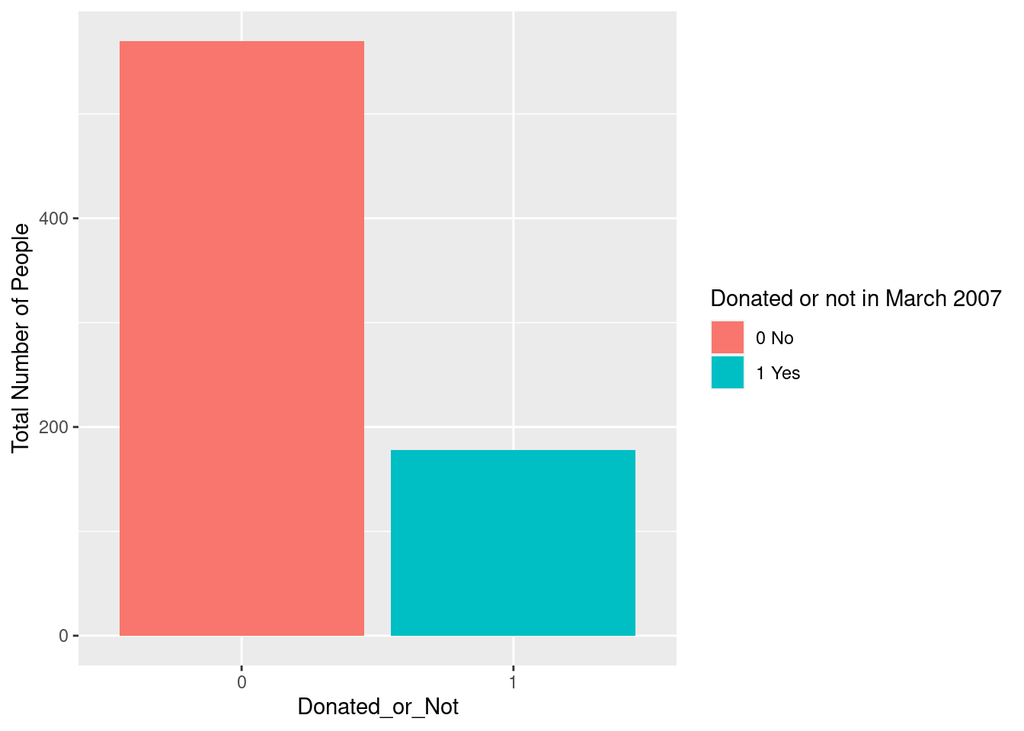

```r
ggplot(bt, aes(x=as.factor(Donated_or_Not), fill=as.factor(Donated_or_Not) )) + geom_bar() + labs(x = "Donated_or_Not", y = "Total Number of People") + scale_fill_discrete(name = "Donated or not in March 2007", labels = c("0 No", "1 Yes"))
```

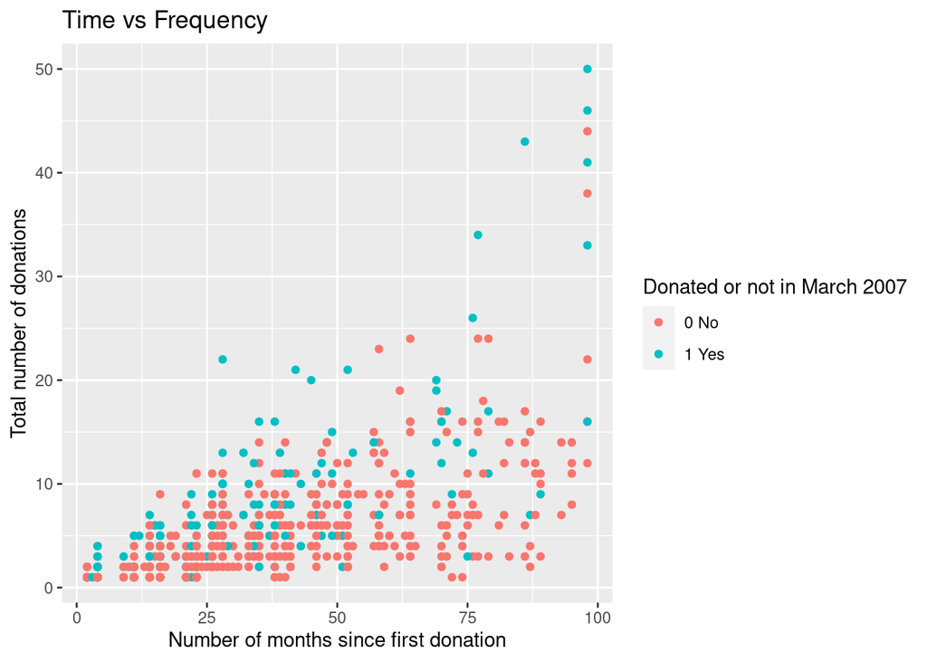

```r
ggplot(bt, aes(x=Time, y=Frequency, color = as.factor(Donated_or_Not))) + geom_point() + labs(title = "Time vs Frequency", y = "Total number of donations", x = "Number of months since first donation") + scale_color_discrete(name = "Donated or not in March 2007", labels = c("0 No", "1 Yes"))
```

After looking at these graphs we can see that the person who donated blood in March 2007 is one third of the person who didn’t donated blood in March 2007. In time vs frequency graph of whether the donor donated blood or not in March 2007, whether a donor donated blood or not is not that different.

# 4 Description and implementation of method(s)

For this project we will use logistic regression to predict the information described in our research question.

- First, we implemented the assumption test to check the prediction for our model looks right.
- Second, in order to see how well we predict, we used rates and probabilities, accuracy, missclassification, sensitivity, specficity, positive and negative predicted value, and confusion matrix.
- Last, we used the crossvalidation method to estimate our test error.

## 4.1 Brief summary of the results

# 5 Evaluation (and comparison) of method(s) in addressing your research goal

## 5.1 Logistic regression

We remove the factor and convert the Donated_or_Not into numeric again.

```r
attach(bt)
bt.model <- glm(Donated_or_Not~., data = bt, family = "binomial")
summary(bt.model)
```

```
##
## Call:
## glm(formula = Donated_or_Not ~ ., family = "binomial", data = bt)
##
## Deviance Residuals:
##     Min       1Q   Median       3Q      Max
## -2.4875  -0.7933  -0.4997  -0.1701   2.6450
##
## Coefficients:
##              Estimate Std. Error z value Pr(>|z|)
## (Intercept) -0.449540   0.180349  -2.493 0.012681 *
## Recency     -0.098584   0.017317  -5.693 1.25e-08 ***
## Frequency    0.135390   0.025672   5.274 1.34e-07 ***
## Time        -0.023092   0.005964  -3.872 0.000108 ***
## ---
## Signif. codes:  0 '***' 0.001 '**' 0.01 '*' 0.05 '.' 0.1 ' ' 1
##
## (Dispersion parameter for binomial family taken to be 1)
##
##     Null deviance: 820.89  on 747  degrees of freedom
## Residual deviance: 707.87  on 744  degrees of freedom
## AIC: 715.87
##
## Number of Fisher Scoring iterations: 5
```

```r
summary(bt.model)$coefficients
```

```
##                Estimate Std. Error   z value     Pr(>|z|)
## (Intercept) -0.44953955 0.18034867 -2.492614 1.268068e-02
## Recency     -0.09858382 0.01731702 -5.692885 1.249102e-08
## Frequency    0.13538952 0.02567212  5.273797 1.336299e-07
## Time        -0.02309249 0.00596427 -3.871805 1.080323e-04
```

```r
# looking at the odds
exp(summary(bt.model)$coefficients[,1])
```

```
## (Intercept)     Recency   Frequency        Time
##   0.6379218   0.9061197   1.1449827   0.9771721
```

All of the variables are statistically significant as all the p-values are less than 0.05 significant level.

After controlling for the variables, Frequency and Time, we find that the relationship between the number of months since the donor’s most recent donation and their odds of donated blood in March 2007 is significant (z-score = -5.692885, p = 1.249102e-08, α = 0.05). Similarly, holding other variables fixed, we can find the relationship between the odds of a person donated blood in March 2007 and each variable, and we find that they are all significant as all p-values are < 0.05. However, the z-score for Recency and Time doesn’t really look good, so we can find OR ratio and see if there’s a relationship.

One unit increase in the total number of donations that the donor has made is associated with 1.145 times greater odds of the donor donated blood in March 2007. Thus, there appears to be a relationship between the total number of donations that the donor has made and the donor donated blood in March 2007. As the strength of the relationship decreases with the inclusion of other covariates, more research is likely needed.

## 5.2 Prediction

In statistical and machine learning, our goal is often prediction. We can use the following equation to predict the probability of an event given values in our predictor space.

$$\hat{p}(X)=\frac{e^{\hat{\beta_0}+\hat{\beta_1}X}}{1+e^{\hat{\beta_0}+\hat{\beta_1}X}}$$
If we have 73 months since the donor’s most recent donation, total number of 48 donations that has made, and 97 months since the donor’s first donation, we get the following.

$$\hat{p}(X)=\frac{e^{-0.44953955+-0.09858382*Recency+0.13538952*Frequency-0.02309249*Time}}{1+e^{-0.44953955+-0.09858382*Recency+0.13538952*Frequency-0.02309249*Time}}$$
This donor has a 0.0327 probability of having donated blood in March 2007. If we wanted a yes/no classification prediction, we could use a threshold of 0.5. A donor with a probability below 0.5 would be predicted to not have donated blood, while a donor with a probability above 0.5 would be predicted to have donated blood in March 2007. For our predicted donor, with 0.03327 < 0.5, woud not be predicted to have donated blood in March 2007.

```r
predicted.values<-predict(bt.model, type="response")
predicted.values[1:5]
```

```
##         1         2         3         4         5
## 0.9793607 0.6601437 0.6920822 0.7353466 0.7156740
```

```r
newdata=data.frame(Recency = 73, Frequency= 48 , Time = 97) ## remember to use the exact same variable names
predict(bt.model, newdata, type="response")
```

```
##          1
## 0.03269053
```

## 5.3 Assumptions

### 5.3.1 Independent Observations

```r
#Durbin Watson test
dwtest(bt.model)
```

```
##
##  Durbin-Watson test
##
## data:  bt.model
## DW = 1.7347, p-value = 0.0001119
## alternative hypothesis: true autocorrelation is greater than 0
```

Even though DW statistic is 1.73, we have a really small p-value, thus, we reject the null hypothesis and conclude that the residuals in this model are auto-correlated.

### 5.3.2 Diagnostic plot

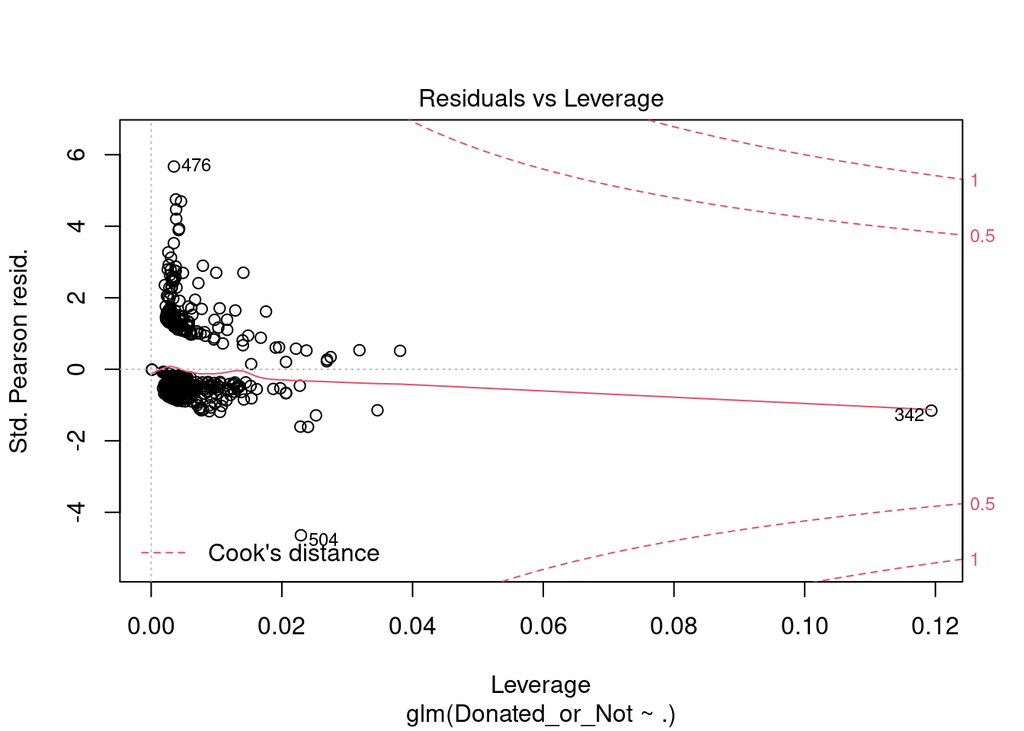

```r
plot(bt.model, which = 5)
```

Since we don’t have any data points outside of the Cook’s distance, we can conclude that we don’t have any influential points in our model.

### 5.3.3 Multicollinearity test

```r
vif(bt.model)
```

```
##   Recency Frequency      Time
##  1.071370  2.261540  2.308866
```

Our values between 1 and 5 indicates moderate correlation between a given predictor variable and other predictor variables in the model, but this is not severe enough to require attention.

### 5.3.4 Number of observations per class

```r
table(Donated_or_Not)
```

```
## Donated_or_Not
##   0   1
## 570 178
```

## 5.4 How well did we predict?

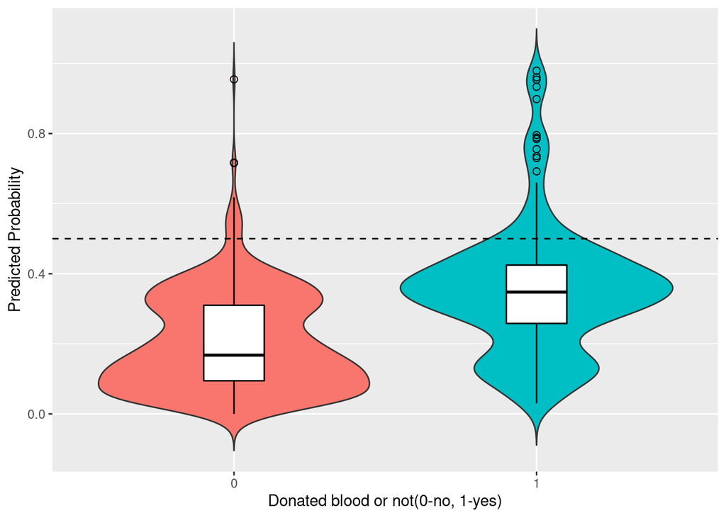

```r
ggplot(bt, aes(y = predicted.values, x = as.factor(Donated_or_Not), fill=as.factor(Donated_or_Not))) +
  geom_violin(trim=FALSE, show.legend=F) +
            geom_boxplot(width=0.2, fill="white", outlier.color="black", outlier.shape=1, color="black", outlier.size=2)  + ylab("Predicted Probability") + xlab("Donated blood or not(0-no, 1-yes)") + geom_hline(yintercept=0.5, linetype="dashed")
```

This violin plot shows the relationship of the Donated blood on March 2007 (yes=1, no=0). The box-plot elements show the median predicted probability for the people who did not donate blood on March 2007 is lower than for the people who donated blood on March 2007. The shape of the distribution (skinny on one end and wide in the middle) indicates the predicted probability of blood donations are concentrated around the median. It also shows that there are more outliers in the case of the people who donated blood in March 2007. Donor who donated blood in March 2007has higher predicted probability to donate blood again. An ideal violin graph will have all values of the people who did not donate blood under the dashed line, while the graph for people who donated blood should be above the dashed line.

### 5.4.1 Confusion Matrix

```r
#Now we changed the 0’s and 1’s to Yes and No:
threshold=0.5
df <- data.frame(predictor = predict(bt.model, bt, type="response"),
                       known.truth = Donated_or_Not)
df$predicted.Donated<-ifelse(df$predictor<threshold,0,1)

df$predicted.Donated[which(df$predicted.Donated == 0)] <- 'No'
df$predicted.Donated[which(df$predicted.Donated == 1)] <- 'Yes'

(trn_tab = table(predicted = df$predicted.Donated, actual = df$known.truth))
```

```
##          actual
## predicted   0   1
##       No  555 156
##       Yes  15  22
```

```r
df$known.truth[which(df$known.truth == 0)] <- 'No'
df$known.truth[which(df$known.truth == 1)] <- 'Yes'

(trn_tab = table(predicted = df$predicted.Donated, actual = df$known.truth))
```

```
##          actual
## predicted  No Yes
##       No  555 156
##       Yes  15  22
```

Here are few other ways of determining how well our prediction/classification perform. For this, we use rates and probabilities with a threshold of 0.5, accuracy for how accurate our model predicted, and misclassification rate for the misclassification of the outcome of the model.

### 5.4.2 Rates and probabilities

```r
#For a particular threshold, we can calculate several probabilities to determine how well our prediction/classification performed.

threshold=0.5
df <- data.frame(predictor = predict(bt.model, bt, type="response"),
                       known.truth = Donated_or_Not)
df$predicted.Donated<-ifelse(df$predictor<threshold,0,1)
table(df$predicted.Donated, df$known.truth)
```

```
##
##       0   1
##   0 555 156
##   1  15  22
```

```r
df.2<-as.data.frame(table(df$predicted.Donated, df$known.truth))
names(df.2)<-c("predicted.Donated", "true.Donated", "count")
```

### 5.4.3 Accuracy

```r
accuracy<-sum(df.2[(df.2$predicted.Donated==1 & df.2$true.Donated==1) | (df.2$predicted.Donated==0 & df.2$true.Donated==0),"count"])/sum(df.2$count)
accuracy
```

```
## [1] 0.7713904
```

For the model, we have 77% accuracy of correct predictions.

### 5.4.4 Misclasification rate

```r
#How often do we misclassify (or incorrectly classify) the outcome
mcr<-1-accuracy
mcr
```

```
## [1] 0.2286096
```

We see that our model have a 23% of predictions were incorrect.

### 5.4.5 Sensitivity

Sensitivity is also called the true positive rate. Here, this is how many do we predict Donated blood on March 2007 out of all people who donated blood on March 2007. If we use M to describe our model prediction of 1 or 0 and D to describe the true class of 1 or 0, we can write the following $sensitivity=P(true.positives | cases)=P(M=1 | D=1)=\frac{N_{true.positives}}{N_{cases}}=\frac{N_{M=1, D=1}}{N_{D=1}}$

```r
tpr<-df.2[df.2$predicted.Donated==1 & df.2$true.Donated==1,"count"]/sum(df.2[df.2$true.Donated==1,"count"])
tpr
```

```
## [1] 0.1235955
```

We can see that our true positive rate is 12.4%.

### 5.4.6 Specificity

Specificity is also called the true negative rate. Here, this is how many do we predict are “did not donated blood on March 2007” out of all people who did not donated blood on March 2007.

$$specificity=P(true.negatives | not.cases)=P(M=0 | D=0)=\frac{N_{true.negatives}}{N_{not.cases}}=\frac{N_{M=0, D=0}}{N_{D=0}}$$

```r
tnr<-df.2[df.2$predicted.Donated==0 & df.2$true.Donated==0,"count"]/sum(df.2[df.2$true.Donated==0,"count"])
tnr
```

```
## [1] 0.9736842
```

We can see that our true negative rate is 97.4%.

### 5.4.7 Positive Predictive Value

Of the people who are predicted to have “Donated blood on March 2007”, how many actually donated blood on March 2007.

$PPV=P(true.positives | positives)=P(D=1 | M=1)=\frac{N_{true.positives}}{N_{positives}}=\frac{N_{D=1, M=1}}{N_{M=1}}$

```r
ppv<-df.2[df.2$predicted.Donated==1 & df.2$true.Donated==1,"count"]/sum(df.2[df.2$predicted.Donated==1,"count"])
ppv
```

```
## [1] 0.5945946
```

We see that 59% of the people actually donated blood out of the people who are predicted to have donated blood in March 2007.

### 5.4.8 Negative Predictive Value

Of the people who were predicted to have not donated blood in March 2007, how many did not actually donate blood in March 2007.

$NPV=P(true.negatives | negatives)=P(D=0 | M=0)=\frac{N_{true.negatives}}{N_{negatives}}=\frac{N_{D=0, M=0}}{N_{M=0}}$

```r
npv<-df.2[df.2$predicted.Donated==0 & df.2$true.Donated==0,"count"]/sum(df.2[df.2$predicted.Donated==0,"count"])
npv
```

```
## [1] 0.7805907
```

We see that 78% of the people did not actually donate blood in March 2007 out of the people who were predicted to have not donated blood in March 2007.

One important additional note. Here, we are evaluating how well the model did on the TRAINING dataset. We would expect the classification to not be as good for a TEST data set. Indeed, classification performance on a test dataset estimates the generalizable error, which is what we are most interested in. Therefore, we will use cross-validation to estimate test error.

## 5.5 Cross Validation

First we need to divide the data:

```r
set.seed(12345)
### We'll select 20% of the data to be test data
test <- sample(c(1:nrow(bt)), floor(nrow(bt)*.2),
                replace = FALSE)
bt_test <- bt[test,]
bt_train <- bt[-c(test),]

y = bt_test$Donated_or_Not
x = model.matrix(~.-1, bt_test[,-4])

dim(bt)
```

```
## [1] 748   4
```

```r
dim(bt_test)
```

```
## [1] 149   4
```

```r
dim(bt_train)
```

```
## [1] 599   4
```

Now, we fit the model

```r
btglm <- glm(Donated_or_Not~., data = bt_train, family = "binomial")
summary(btglm)
```

```
##
## Call:
## glm(formula = Donated_or_Not ~ ., family = "binomial", data = bt_train)
##
## Deviance Residuals:
##     Min       1Q   Median       3Q      Max
## -1.6178  -0.7866  -0.5068  -0.2445   2.6086
##
## Coefficients:
##              Estimate Std. Error z value Pr(>|z|)
## (Intercept) -0.567637   0.205451  -2.763 0.005729 **
## Recency     -0.091130   0.018887  -4.825 1.40e-06 ***
## Frequency    0.142647   0.028726   4.966 6.84e-07 ***
## Time        -0.023363   0.006576  -3.553 0.000381 ***
## ---
## Signif. codes:  0 '***' 0.001 '**' 0.01 '*' 0.05 '.' 0.1 ' ' 1
##
## (Dispersion parameter for binomial family taken to be 1)
##
##     Null deviance: 644.19  on 598  degrees of freedom
## Residual deviance: 561.76  on 595  degrees of freedom
## AIC: 569.76
##
## Number of Fisher Scoring iterations: 5
```

```r
probs <- predict(btglm, newdata = bt_test, type = "response")
pred.glm <- rep(0, length(probs))
pred.glm[probs > 0.5] <- 1
```

Compute the validation set error, which is the fraction of the observations in the validation set that are misclassified.

```r
mean(pred.glm != bt_test$Donated_or_Not)
```

```
## [1] 0.2550336
```

```r
fit.glm <- glm(Donated_or_Not~., data = bt_train, family = "binomial")
summary(fit.glm)
```

```
##
## Call:
## glm(formula = Donated_or_Not ~ ., family = "binomial", data = bt_train)
##
## Deviance Residuals:
##     Min       1Q   Median       3Q      Max
## -1.6178  -0.7866  -0.5068  -0.2445   2.6086
##
## Coefficients:
##              Estimate Std. Error z value Pr(>|z|)
## (Intercept) -0.567637   0.205451  -2.763 0.005729 **
## Recency     -0.091130   0.018887  -4.825 1.40e-06 ***
## Frequency    0.142647   0.028726   4.966 6.84e-07 ***
## Time        -0.023363   0.006576  -3.553 0.000381 ***
## ---
## Signif. codes:  0 '***' 0.001 '**' 0.01 '*' 0.05 '.' 0.1 ' ' 1
##
## (Dispersion parameter for binomial family taken to be 1)
##
##     Null deviance: 644.19  on 598  degrees of freedom
## Residual deviance: 561.76  on 595  degrees of freedom
## AIC: 569.76
##
## Number of Fisher Scoring iterations: 5
```

```r
predict.glm(fit.glm, bt_test[1, ], type = "response") > 0.5
```

```
##     1
## FALSE
```

```r
error <- rep(0, dim(bt)[1])
for (i in 1:dim(bt)[1]) {
    fit.glm <- glm(Donated_or_Not~., data = bt[-i, ],  family = "binomial")
    pred.1 <- predict.glm(fit.glm, bt[i, ], type = "response") > 0.5
    true.1 <- bt[i, ]$Donated_or_Not == 1
    if (pred.1 != true.1)
        error[i] <- 1
}
error
```

[output not shown]

Now we calculate the validation set error, which is the fraction of the observations in the validation set that are misclassified.

```r
mean(error)
```

```
## [1] 0.2299465
```

# 6 Discussion/conclusion

# 7 References

ISLRv2: https://hastie.su.domains/ISLR2/ISLRv2_website.pdf

Jovian-Predicting if a Blood Donor will donate within a given time window…: https://blog.jovian.ai/predicting-if-a-blood-donor-will-donate-within-a-given-time-window-8dbf41a4fe97

Examples from the class and previous projects

# 8 Appendix

Link to Data Set: https://code.datasciencedojo.com/datasciencedojo/datasets/blob/master/Blood%20Transfusion%20Service%20Center/transfusion.data.csv